# Truncated time-to-event data: in-class R exercises (instructor key)

Harvard Catalyst Biostatistics Short Course, October 23, 2026

Jing Qian (qian@umass.edu)

**Instructor key**: the student file plus an answer after each **Try it**, with the expected output in comments (R 4.3.3, survival 3.5-8, tranSurv 1.2.4).

Short examples to run during the class, one block per part. Each block runs on its own in under a minute. Run the code, compare the output with the slide, then do the **Try it** step below the block. The full course code is in `Harvard-course-R-code.R`.

# Setup

Needs survival, boot and gss (Overview, Parts I, II and IV) and tranSurv 1.2.3 or later (Part III). coxrt and seqTrun are optional extras.

```r
pkgs <- c("survival", "boot", "gss", "tranSurv")
new_pkgs <- setdiff(pkgs, rownames(installed.packages()))
if (length(new_pkgs) > 0) install.packages(new_pkgs)
library(survival)
```

# Overview: who is in the risk set?

Five people; A dies at time 15. E only enters the study at time 17, so a death of E at time 15 could never have been seen.

```r
toy <- data.frame(id    = c("A", "B", "C", "D", "E"),
                  entry = c(0, 3, 6, 9, 17),
                  exit  = c(15, 20, 24, 30, 26),
                  event = c(1, 0, 1, 0, 1))
naive <- survfit(Surv(exit, event) ~ 1, data = toy)          # ignores entry
fixed <- survfit(Surv(entry, exit, event) ~ 1, data = toy)   # delayed entry
summary(naive, times = 15)$n.risk   # 5 at risk: hazard 1/5
```

```
#> [1] 5
```

```r
summary(fixed, times = 15)$n.risk   # 4 at risk: hazard 1/4
```

```
#> [1] 4
```

**Try it.** Change E’s entry time from 17 to 12. How many are at risk at time 15 in each analysis now, and why?

```r
## >>> Answer
toy2 <- transform(toy, entry = replace(entry, id == "E", 12))
summary(survfit(Surv(exit, event) ~ 1, data = toy2), times = 15)$n.risk          # 5
```

```
#> [1] 5
```

```r
summary(survfit(Surv(entry, exit, event) ~ 1, data = toy2), times = 15)$n.risk   # 5
```

```
#> [1] 5
```

```r
## E has entered before 15, so it belongs in the risk set; the two analyses agree.
## Delayed entry only matters for people who enter after the event time.
```

## Overview: GENIE BPC colorectal cancer (needs internet)

Stage IV colorectal cancer; time zero is diagnosis, and patients enter the database when their tumor is sequenced (Brown et al., JAMA Oncol 2022; public data).

```r
url <- paste0("https://raw.githubusercontent.com/slb2240/",
              "delayed_entry_clin_genom_studies/main/crc_stage_iv_os_dx_data.csv")
crc <- read.csv(url)
crc <- with(crc, data.frame(dx_to_seq   = tt_cpt_report_mos,   # entry (months)
                            dx_to_death = tt_os_dx_mos,        # death or last contact
                            died        = os_status_dx))
survfit(Surv(dx_to_death, died) ~ 1, data = crc)              # naive: median 38.1
```

```
#> Call: survfit(formula = Surv(dx_to_death, died) ~ 1, data = crc)
#>
#>        n events median 0.95LCL 0.95UCL
#> [1,] 659    425   38.1    34.4    41.2
```

```r
survfit(Surv(dx_to_seq, dx_to_death, died) ~ 1, data = crc)   # delayed entry: median 25.1
```

```
#> Call: survfit(formula = Surv(dx_to_seq, dx_to_death, died) ~ 1, data = crc)
#>
#>      records n.max n.start events median 0.95LCL 0.95UCL
#> [1,]     659   350      27    425   25.1    22.3    29.1
```

**Try it.** Move time zero to the day of sequencing: analyze `seq_to_death = dx_to_death - dx_to_seq`. Is there still delayed entry? What question does this median answer?

```r
## >>> Answer
crc$seq_to_death <- crc$dx_to_death - crc$dx_to_seq
survfit(Surv(seq_to_death, died) ~ 1, data = crc)   # median 21.6 months
```

```
#> Call: survfit(formula = Surv(seq_to_death, died) ~ 1, data = crc)
#>
#>        n events median 0.95LCL 0.95UCL
#> [1,] 659    425   21.6      20    24.7
```

```r
## No: everyone enters at their own time zero, so the ordinary Kaplan-Meier is fine.
## But it answers a different question: survival from sequencing among sequenced
## patients, not survival from diagnosis. Choose time zero first, then handle entry.
```

# Part I: Channing House (left truncation)

Ages in months (converted to years). Time zero is birth; residents are observable once they moved in alive. Despite its name, `cens = 1` means **died**.

```r
library(boot)   # channing
ch <- transform(channing, entry = entry/12, exit = exit/12)
fw <- subset(ch, entry < exit & sex == "Female")
naive <- survfit(Surv(exit, cens) ~ 1, data = fw)
fixed <- survfit(Surv(entry, exit, cens) ~ 1, data = fw)
naive   # median age at death 88.0
```

```
#> Call: survfit(formula = Surv(exit, cens) ~ 1, data = fw)
#>
#>        n events median 0.95LCL 0.95UCL
#> [1,] 361    129     88    86.7    90.2
```

```r
fixed   # median age at death 84.8
```

```
#> Call: survfit(formula = Surv(entry, exit, cens) ~ 1, data = fw)
#>
#>      records n.max n.start events median 0.95LCL 0.95UCL
#> [1,]     361   166      17    129   84.8    83.2    86.8
```

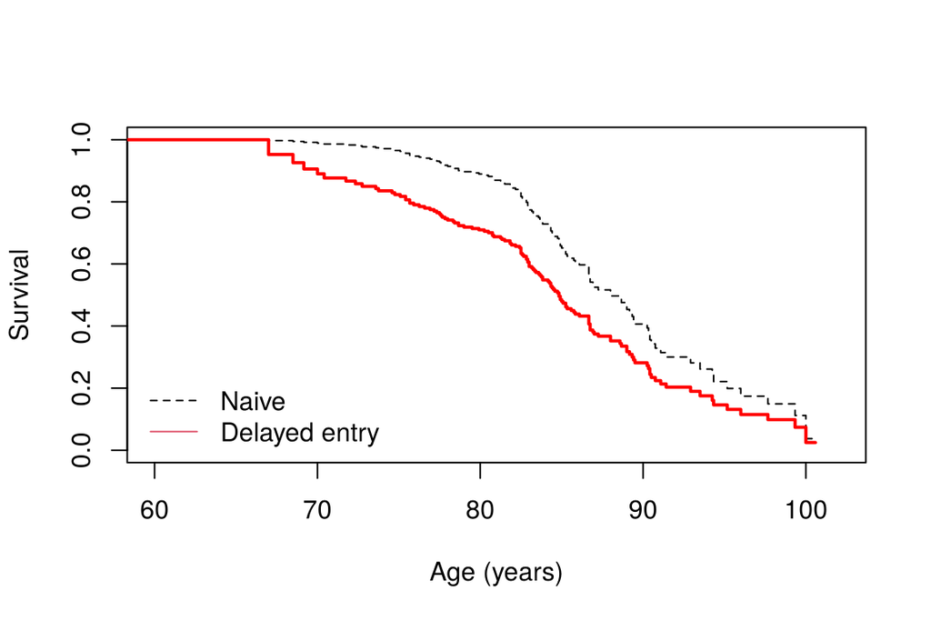

```r
plot(naive, conf.int = FALSE, lty = 2, xlim = c(60, 102),
     xlab = "Age (years)", ylab = "Survival")
lines(fixed, conf.int = FALSE, col = "red", lwd = 2)
legend("bottomleft", c("Naive", "Delayed entry"), lty = c(2, 1), col = c(1, 2), bty = "n")
```

**Try it.** (1) Repeat the delayed-entry analysis for **men**. Look at the first rows of `summary()`: how many men are at risk at the first two deaths, and what happens to the curve? (2) Refit with `start.time = 68`. What does the median now estimate?

```r
## >>> Answer
fm <- subset(ch, entry < exit & sex == "Male")
fixed_m <- survfit(Surv(entry, exit, cens) ~ 1, data = fm)
head(summary(fixed_m)$n.risk, 3)   # 2, 1, ...: the curve halves, then drops to 0 at 65.1
```

```
#> [1]  2  1 24
```

```r
fixed_m68 <- survfit(Surv(entry, exit, cens) ~ 1, data = fm, start.time = 68)
fixed_m68                          # median 84.1: median age at death GIVEN alive at 68
```

```
#> Call: survfit(formula = Surv(entry, exit, cens) ~ 1, data = fm, start.time = 68)
#>
#>      records n.max n.start events median 0.95LCL 0.95UCL
#> [1,]      94    39      12     44   84.1    80.5    86.9
```

```r
## Few men entered before 65, so the early risk sets are tiny and the curve collapses.
## start.time = 68 changes the target to S(x | alive at 68); it does not repair the
## curve before 68.
```

## Part I: right truncation, transfusion AIDS

`incu`: infection to AIDS ($X^*$); `infe`: infection to the July 1986 cutoff ($T^*$). A case is in the data only if $X^* \le T^*$. Reverse time, then use delayed entry.

```r
library(gss); data(aids)   # months
shift <- max(aids$infe)    # reversal constant c (any c >= 99)
fit <- survfit(Surv(shift - infe - 0.5, shift - incu, rep(1, 295)) ~ 1, data = aids)
## Back to the original scale: F(x | X* <= 99) = S_X((shift - x)-)
F_rt <- function(x) sapply(x, function(u) {
  k <- which(fit$time < shift - u)
  if (length(k) == 0) 1 else fit$surv[max(k)]
})
median(aids$incu)                         # naive median incubation: 29 months
```

```
#> [1] 29
```

```r
(0:99)[min(which(F_rt(0:99) >= 0.5))]     # corrected: 68 months (given <= 99 months)
```

```
#> [1] 68
```

**Try it.** Use `shift <- 150` instead of `max(aids$infe)` and rerun the block. Does the corrected median change? Why or why not?

```r
## >>> Answer
shift <- 150
fit <- survfit(Surv(shift - infe - 0.5, shift - incu, rep(1, 295)) ~ 1, data = aids)
(0:99)[min(which(F_rt(0:99) >= 0.5))]     # still 68
```

```
#> [1] 68
```

```r
## The constant only shifts the time axis; the risk sets and the estimate are the same.
```

# Part II: Cox regression with delayed entry (flchain)

Residents aged 50+ enter at the age of their blood draw. Exposure: top decile of free light chain (FLC). Time scale: age.

```r
fl <- subset(flchain, futime > 0)             # drop entry >= exit (3 rows)
fl$age_exit <- fl$age + fl$futime / 365.25    # age at death or last contact
fl$high <- as.numeric(fl$flc.grp == 10)       # top FLC decile
m_naive <- coxph(Surv(age_exit, death) ~ high + sex, data = fl)        # HR 1.33
m_age   <- coxph(Surv(age, age_exit, death) ~ high + sex, data = fl)   # HR 2.27
m_study <- coxph(Surv(futime, death) ~ high + sex + age, data = fl)    # HR 2.13
round(rbind(naive = summary(m_naive)$conf.int["high", c(1, 3, 4)],
            delayed_entry = summary(m_age)$conf.int["high", c(1, 3, 4)],
            time_on_study = summary(m_study)$conf.int["high", c(1, 3, 4)]), 2)
```

```
#>               exp(coef) lower .95 upper .95
#> naive              1.33      1.20      1.47
#> delayed_entry      2.27      2.04      2.52
#> time_on_study      2.13      1.92      2.37
```

**Try it.** (1) Why does ignoring entry age shrink the hazard ratio? Compare the entry ages of the two FLC groups. (2) Using `m_age`, estimate the median age at death for women **alive at 65**, by FLC group: `survfit(m_age, newdata = ..., start.time = 65)`.

```r
## >>> Answer
tapply(fl$age, fl$high, median)   # 62 (other) vs 73 (top decile)
```

```
#>  0  1
#> 62 73
```

```r
## High-FLC people enter about 11 years older, so the naive analysis credits them with
## more time before entry during which they could not have died in the study. Their
## hazard looks too low, and the HR is pulled toward 1.
sf65 <- survfit(m_age, newdata = data.frame(high = c(0, 1), sex = "F"), start.time = 65)
summary(sf65)$table[, "median"]   # 87.1 (other) vs 80.4 (top decile)
```

```
#>       1       2
#> 87.1499 80.3922
```

## Part II: right truncation, IPW Cox (transfusion AIDS)

Do recipients aged $\le$ 59 develop AIDS faster? Keep the 116 people infected in 1983 or later. Each case is weighted by $1/\Pr(R > x)$, its inverse chance of being seen.

```r
data(aids, package = "gss")
d <- data.frame(X = pmax(aids$incu, 0.5),    # infection -> AIDS (months)
                R = aids$infe,               # infection -> June 30, 1986
                young = as.numeric(aids$age <= 59))
d <- subset(d, 102 - R > 60)                 # infected in 1983 or later: n = 116
fR <- survfit(Surv(X, R, rep(1, nrow(d))) ~ 1, data = d, stype = 2)  # R left-truncated by X
d$w <- 1 / stepfun(fR$time, c(1, fR$surv))(d$X)                      # w = 1 / Pr(R > X)
coxph(Surv(X) ~ young, data = d)                    # naive: HR 1.83
```

```
#> Call:
#> coxph(formula = Surv(X) ~ young, data = d)
#>
#>         coef exp(coef) se(coef)     z       p
#> young 0.6044    1.8302   0.1920 3.149 0.00164
#>
#> Likelihood ratio test=9.85  on 1 df, p=0.001695
#> n= 116, number of events= 116
```

```r
coxph(Surv(X) ~ young + offset(log(w)), data = d)   # IPW: HR 3.24 (printed SE too small)
```

```
#> Call:
#> coxph(formula = Surv(X) ~ young + offset(log(w)), data = d)
#>
#>         coef exp(coef) se(coef)     z        p
#> young 1.1754    3.2395   0.1925 6.106 1.02e-09
#>
#> Likelihood ratio test=36.01  on 1 df, p=1.961e-09
#> n= 116, number of events= 116
```

**Try it.** (1) Inspect the weights: what are the median and the largest weight, and what share of the total weight do the top 5% of cases carry? (2) If `coxrt` is installed, get the correct SE with `coxrt::coxph.RT(X ~ young, right = R, data = d)`.

```r
## >>> Answer
summary(d$w)                                                     # median 1.5, max 35
```

```
#>    Min. 1st Qu.  Median    Mean 3rd Qu.    Max.
#>   1.000   1.232   1.470   2.404   2.015  34.981
```

```r
sum(sort(d$w, decreasing = TRUE)[1:ceiling(0.05 * nrow(d))]) / sum(d$w)   # 0.31
```

```
#> [1] 0.310589
```

```r
if (requireNamespace("coxrt", quietly = TRUE)) {
  rt <- coxrt::coxph.RT(X ~ young, right = R, data = d)
  print(round(exp(unlist(rt$summary[, c("coef", "CI.L", "CI.U")])), 2))   # 3.24 (1.53, 6.85)
}
```

```
#> coef CI.L CI.U
#> 3.24 1.53 6.85
```

```r
## The longest incubations get the largest weights, so a few cases drive the estimate.
## The analytic SE (0.38) is twice the SE coxph() prints (0.19).
```

# Part III: is entry quasi-independent of death?

Channing House again, ages in **months**. tranSurv must be version 1.2.3 or later.

```r
library(tranSurv)
packageVersion("tranSurv")
```

```
#> [1] '1.2.4'
```

```r
data(channing, package = "boot")
chan <- subset(channing, entry < exit)                     # n = 457, 175 deaths
with(chan, cKendall(entry, exit, cens))                    # tau 0.085, p = 0.074
```

```
#>
#>  Test for quasi-independence with conditional Kendall's tau
#>
#>  Call: cKendall(trun = entry, obs = exit, delta = cens)
#>
#>  Kendall's tau = 0.085 , SE = 0.0476 , Z = 1.7845 , p-value =  0.0743
```

```r
with(chan, cKendall(entry, exit, cens, method = "IPW2"))   # tau 0.444, p < 0.001 (prints 0)
```

```
#>
#>  Test for quasi-independence with conditional Kendall's tau
#>
#>  Call: cKendall(trun = entry, obs = exit, delta = cens, method = "IPW2")
#>
#>  Kendall's tau = 0.4436 , SE = 0.0959 , Z = 4.6234 , p-value =  0
```

```r
coxph(Surv(entry, exit, cens) ~ sex, data = chan)          # Cox QI: male 0.322
```

```
#> Call:
#> coxph(formula = Surv(entry, exit, cens) ~ sex, data = chan)
#>
#>           coef exp(coef) se(coef)     z      p
#> sexMale 0.3219    1.3798   0.1733 1.857 0.0633
#>
#> Likelihood ratio test=3.28  on 1 df, p=0.07021
#> n= 457, number of events= 175
```

```r
trReg(Surv(entry, exit, cens) ~ sex, data = chan)          # CK: a = -0.80, male 0.489
```

```
#>
#>  Call:trReg(formula = Surv(entry, exit, cens) ~ sex, data = chan)
#>
#>  Sample size = 457
#>  Number of events =  175
#>
#>  Transformation parameter is -0.8028036
#>
#>  Standard errors obtained from 0 bootstrap samples.
#>          coef se(coef)  z Pr(>|z|)
#> sexMale 0.489       NA NA       NA
```

**Try it.** (1) Test quasi-independence separately for women and men. Do the pooled and within-sex tests agree? (2) Fit the Cox2 version (about 15 seconds): `trReg(..., method = "adjust", control = list(Q = 2))`.

```r
## >>> Answer
with(subset(chan, sex == "Female"), cKendall(entry, exit, cens))   # 0.05, p = 0.35
```

```
#>
#>  Test for quasi-independence with conditional Kendall's tau
#>
#>  Call: cKendall(trun = entry, obs = exit, delta = cens)
#>
#>  Kendall's tau = 0.0513 , SE = 0.0552 , Z = 0.9291 , p-value =  0.3528
```

```r
with(subset(chan, sex == "Male"), cKendall(entry, exit, cens))     # 0.20, p = 0.04
```

```
#>
#>  Test for quasi-independence with conditional Kendall's tau
#>
#>  Call: cKendall(trun = entry, obs = exit, delta = cens)
#>
#>  Kendall's tau = 0.1967 , SE = 0.0958 , Z = 2.0529 , p-value =  0.0401
```

```r
## Not fully: no evidence of dependence for women, some for men. A pooled test is not a
## test of quasi-independence given covariates, which is what Cox regression needs.
trReg(Surv(entry, exit, cens) ~ sex, data = chan,
      method = "adjust", control = list(Q = 2))                     # a = -0.87, male 0.356
```

```
#>
#>  Call:trReg(formula = Surv(entry, exit, cens) ~ sex, data = chan, method = "adjust",
#>     control = list(Q = 2))
#>
#>  Sample size = 457
#>  Number of events =  175
#>
#>  Transformation parameter is -0.8724685
#>
#>  Standard errors obtained from 0 bootstrap samples.
#>          coef se(coef)  z Pr(>|z|)
#> sexMale 0.356       NA NA       NA
#>
#>
#>  Coefficient estimates for transformed truncation times used in the adjusted model:
#>                               coef se(coef)      z Pr(>|z|)
#> T'(a) in (-Inf, 306.133]    -0.255    0.081 -3.161    0.002 **
#> T'(a) in (306.133, 621.481]  0.280    0.094  2.969    0.003 **
#> ---
#> Signif. codes:  0 '***' 0.001 '**' 0.01 '*' 0.05 '.' 0.1 ' ' 1
```

```r
## The male effect ranges from 0.32 to 0.49 across truncation models: report them side
## by side as a sensitivity analysis.
```

# Part IV: sequential truncation, the fix as weighting

Setup 2 of Betensky, Qian and Hou (2023): $L$ = onset age, $X = L + U$ = entry age, $R$ = death age, observed only if $L < X < R$; $\Pr(X < R) = 0.15$. Weight each person by $1/\Pr(R > x_j)$ (NPMLE) and compare with the two shortcuts.

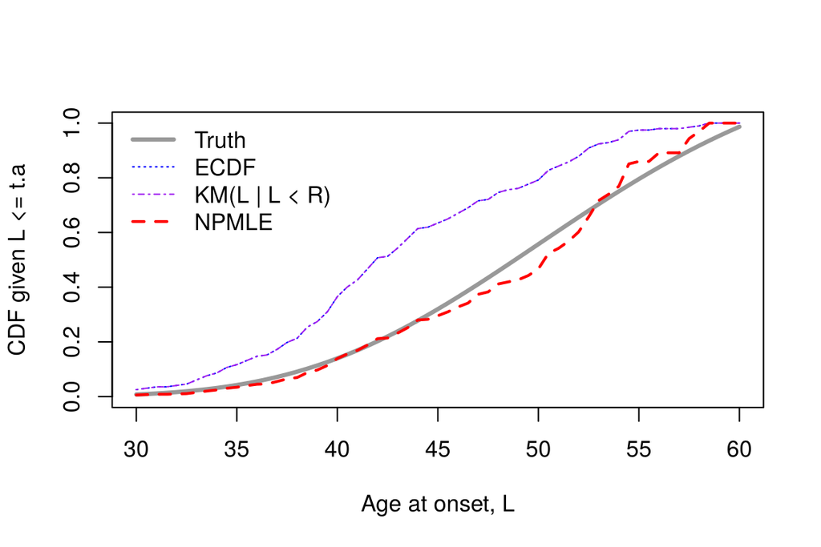

```r
sim_seq <- function(n, r.shape) {     # keep sampling until n people satisfy X < R
  out <- NULL
  while (NROW(out) < n) {
    l <- rgamma(n, 26, 0.5); x <- l + runif(n, 24, 34); r <- rgamma(n, r.shape, 0.5)
    out <- rbind(out, cbind(l, x, r)[x < r, , drop = FALSE])
  }
  out[1:n, ]
}
set.seed(2026)
n <- 200
dat <- sim_seq(n, r.shape = 32.4)     # Pr(X < R) = 0.15
t.a <- 60.43                          # largest L we expect to see; estimate F_L given L <= t.a
l <- dat[, "l"]; x <- dat[, "x"]; r <- dat[, "r"]
S_R <- function(fit) stepfun(fit$time, c(1, fit$surv))
w_x <- 1 / S_R(survfit(Surv(x, r, rep(1, n)) ~ 1))(x)   # NPMLE: 1 / Pr(R > x_j)
w_l <- 1 / S_R(survfit(Surv(l, r, rep(1, n)) ~ 1))(l)   # KM(L | L < R): 1 / Pr(R > l_j)
F_w <- function(u, w) {                                  # weighted CDF of L, given L <= t.a
  F <- sapply(c(u, t.a), function(v) sum(w * (l <= v)) / sum(w))
  F[seq_along(u)] / F[length(u) + 1]
}
u <- seq(30, t.a, by = 0.5)
truth <- pgamma(u, 26, 0.5) / pgamma(t.a, 26, 0.5)
plot(u, truth, type = "l", lwd = 3, col = "grey60", ylim = c(0, 1),
     xlab = "Age at onset, L", ylab = "CDF given L <= t.a")
lines(u, F_w(u, rep(1, n)), lty = 3, col = "blue")      # ECDF
lines(u, F_w(u, w_l), lty = 4, col = "purple")          # KM(L | L < R)
lines(u, F_w(u, w_x), lty = 2, lwd = 2, col = "red")    # NPMLE
legend("topleft", c("Truth", "ECDF", "KM(L | L < R)", "NPMLE"), bty = "n",
       lty = c(1, 3, 4, 2), lwd = c(3, 1, 1, 2), col = c("grey60", "blue", "purple", "red"))
```

```r
## CDF at the true median age at onset (truth 0.50): ECDF 0.76, KM 0.76, NPMLE 0.43
round(c(ECDF = F_w(u, rep(1, n))[which.min(abs(truth - 0.5))],
        KM_LR = F_w(u, w_l)[which.min(abs(truth - 0.5))],
        NPMLE = F_w(u, w_x)[which.min(abs(truth - 0.5))]), 2)
```

```
#>  ECDF KM_LR NPMLE
#>  0.76  0.76  0.43
```

**Try it.** Change to light truncation, `r.shape = 47.5` ($\Pr(X < R) = 0.80$) with `t.a <- 69.78`, and rerun the block. How do the shortcuts compare with the NPMLE now? (If any weight is `Inf`, the KM for $R$ hit 0; rerun with another seed.)

```r
## >>> Answer
set.seed(2026)
dat <- sim_seq(n, r.shape = 47.5); t.a <- 69.78
l <- dat[, "l"]; x <- dat[, "x"]; r <- dat[, "r"]
w_x <- 1 / S_R(survfit(Surv(x, r, rep(1, n)) ~ 1))(x)
w_l <- 1 / S_R(survfit(Surv(l, r, rep(1, n)) ~ 1))(l)
u <- seq(30, t.a, by = 0.5)
truth <- pgamma(u, 26, 0.5) / pgamma(t.a, 26, 0.5)
k <- which.min(abs(truth - 0.5))
round(c(ECDF = F_w(u, rep(1, n))[k], KM_LR = F_w(u, w_l)[k], NPMLE = F_w(u, w_x)[k]), 2)
```

```
#>  ECDF KM_LR NPMLE
#>  0.54  0.54  0.46
```

```r
## ECDF 0.54, KM 0.54, NPMLE 0.46 (truth 0.50): with light truncation all three are
## within sampling error of the truth. With Pr(X < R) = 0.15 the shortcuts were at 0.76
## and the NPMLE at 0.43: the shortcuts' bias grows as Pr(X < R) falls, and the two
## shortcuts agree here because L and R barely overlap.
```